# Limiting vertical HIV transmission: A study of antiretroviral therapy duration among pregnant women

Lindsay Glang

# Dataset Source

*Chagomerana, Maganizo B. et al. (2019), Data from: Optimizing prevention of HIV mother to child transmission: duration of antiretroviral therapy and viral suppression at delivery among pregnant Malawian women, Dryad, Dataset, https://doi.org/10.5061/dryad.sk2pg32. Dataset stored on personal github to prevent changes.*

# Background

Human immunodeficiency virus (HIV) is considered a global epidemic by the World Health Organization, affecting over 37 million people worldwide. In 2018 an estimated 1071000 out of 1300000 pregnant women (approximately 82%) recieved antiretroviral treatment for prevention of mother-to-child transmission (MTCT, vertical transmission). [Data from the WHO](https://www.who.int/data/gho/data/indicators/indicator-details/GHO/estimated-percentage-of-pregnant-women-living-with-hiv-who-received-antiretrovirals-for-preventing-mother-to-child-transmission). A study by Chagomerana et al evaluated the association between duration of antiretroviral therapy (ART) and viral suppression by the time of delivery.

# Methods

The study focused on a cohort of 299 women initiating ART at a hospital in Malawi, Africa. All women were over the age of 16, and had either never been exposed to ART or had only minimal, single dose treatment. Duration of ART was measured in weeks from start date to delivery date (3 catagories: <12 weeks, 13-20 weeks, 21-35 weeks). CD4 cell count and viral load were measured using laboratory techniques with a viral load (VL) limit of detection at 40 copies/mL. A failure to achieve sufficent viral suppression was shown if VL>1000 copies/mL, and a failure to achieve complete suppression was shown if VL>40 copies/mL.

# Trends

Figure 1 shows some overarching trends of the data, a bargraph showing the number of women who achieved some or all viral suppression after ART, and a heatmap showing how the duration of ART affected the level of suppression. According to these trends, the majority of women achieved complete viral suppression, with a greater level of effect when they had taken the therapy for a longer period of time.

# Statistics

Figure 2 shows boxplots of the viral loads at the start of ART, and at the time of delivery, broken down into viral loads > 1000 (insufficient suppression), and loads > 40 (sufficient suppression - it is assumed that sufficient suppression includes viral loads > 40 but <1000). On the graphs, a 0 represents a viral load under 1000 or 40, and a 1 represents a viral load over 1000 or 40. In both cases (VL>1000, VL>40), there is no significance between the starting load and whether viral suppression was insufficient, sufficient, or total. (VL>1000 had a p-value of 0.83, and VL>40 had a p-value of 0.06.)

# Conclusions

From the analysis, it seems any amount of antiretroviral therapy is better than none at all, and it has an overwhelmingly positive effect on viral load at the time of delivery. There doesn’t appear to be a statistical negative consequence on having a higher starting viral load and achieving either sufficient or total viral suppression. There is a positive correlation between a longer duration of ART and achieving total viral suppression. Not included in this current analysis (though included in the original study) is the effect of adherence to the ART, which may cause some bias.

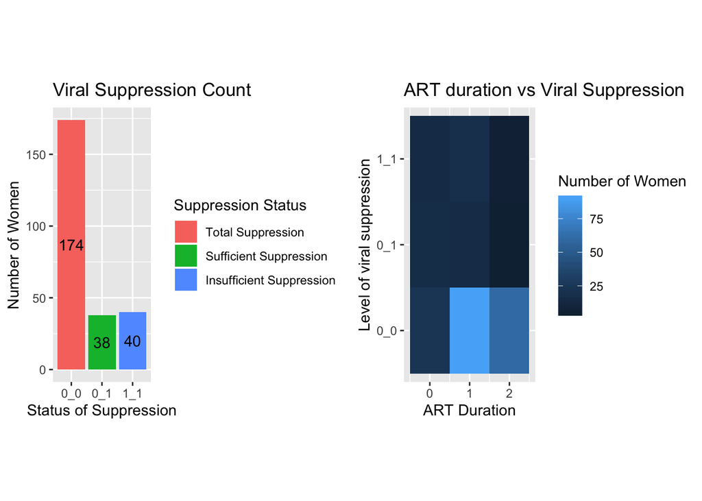

Figure 1: Summary Figures

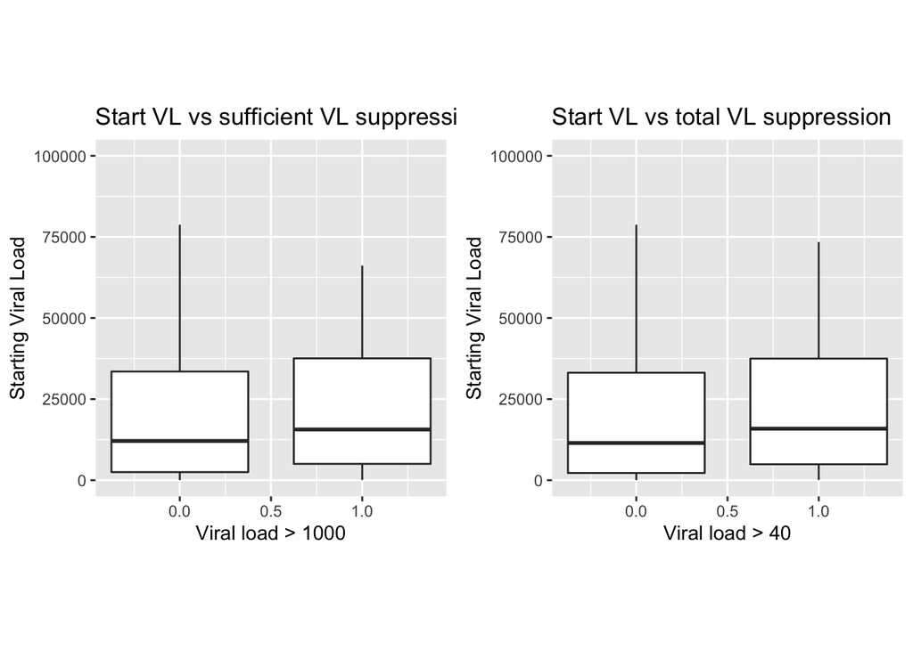